# Data Wrangling 10-4-2025

## Part 1: NumPy Fundamentals

NumPy (Numerical Python) is the fundamental package for numerical computation in Python.

```python
import numpy as np

# Basic variables
a = 7
b = 2

# Square root function - calculates square root of b (which is 2)
print(np.sqrt(b))  # Output: 1.4142... (square root of 2)
```

```
1.4142135623730951
```

### Creating Arrays

```python
# Create a vector (1D array) of zeros with 5 elements
# All elements are initialized to 0.0 (float)
vector = np.zeros(5)
print("Zeros vector:", vector)

# Create a vector of ones with 5 elements
ones = np.ones(5)
print("Ones vector:", ones)

# Modify specific elements in the vector
vector[0] = a   # First element (index 0) becomes 7
vector[-1] = b  # Last element (index -1) becomes 2
print("Modified vector:", vector)
```

```
Zeros vector: [0. 0. 0. 0. 0.]
Ones vector: [1. 1. 1. 1. 1.]
Modified vector: [7. 0. 0. 0. 2.]
```

### Array Operations and Functions

```python
# Create an array from a list
vector_a = np.array([1, 2, 34, 7])
print("Vector A:", vector_a)

# Apply square root to each element of the vector
sqrt_vector = np.sqrt(vector_a)
print("Square root of vector:", sqrt_vector)
```

```
Vector A: [ 1  2 34  7]
Square root of vector: [1.         1.41421356 5.83095189 2.64575131]
```

### Working with Matrices (2D Arrays)

```python
# Create a 3x4 matrix (2D array) filled with zeros
matrix = np.zeros((3, 4))  # 3 rows, 4 columns
print("Initial matrix:\n", matrix)

# Modify a specific element (row 0, column 1)
matrix[0, 1] = a
print("\n Modified matrix: \n", matrix)

# Matrix properties
print("\nMatrix shape (rows, columns):", matrix.shape)
print("Matrix size (total elements):", matrix.size)
```

```
Initial matrix:
 [[0. 0. 0. 0.]
 [0. 0. 0. 0.]
 [0. 0. 0. 0.]]

 Modified matrix:
 [[0. 7. 0. 0.]
 [0. 0. 0. 0.]
 [0. 0. 0. 0.]]

Matrix shape (rows, columns): (3, 4)
Matrix size (total elements): 12
```

### Matrix Operations

```python
# Create a row vector of ones with same number of rows as matrix
ones = np.ones((1, matrix.shape[0]))  # 1 row, 3 columns
print("Ones vector shape:", ones.shape)

# Matrix multiplication: ones (1x3) * matrix (3x4) = result (1x4)
matrix_new = np.matmul(ones, matrix)
print("Matrix multiplication result:\n", matrix_new)

# Create a 5x5 identity matrix
matrix_identity = np.eye(5)
print("\n5x5 Identity matrix:\n", matrix_identity)
```

```
Ones vector shape: (1, 3)
Matrix multiplication result:
 [[0. 7. 0. 0.]]

5x5 Identity matrix:
 [[1. 0. 0. 0. 0.]
 [0. 1. 0. 0. 0.]
 [0. 0. 1. 0. 0.]
 [0. 0. 0. 1. 0.]
 [0. 0. 0. 0. 1.]]
```

### Statistical Operations

```python
# Basic statistics on matrices
print("Matrix sum:", matrix.sum())      # Sum of all elements
print("Matrix mean:", matrix.mean())    # Average of all elements
print("Matrix standard deviation:", matrix.std())  # Standard deviation
```

```
Matrix sum: 7.0
Matrix mean: 0.5833333333333334
Matrix standard deviation: 1.9346977943739836
```

### Creating Sequences

```python
# Create sequence from 1 to 10 with step 0.1
idx = np.arange(1, 5, 0.1)
print("arange result length:", len(idx))
print("First 5 elements:", idx[:5])
print(idx)
# Create 100 equally spaced points between 1 and 10
# idx = np.linspace(1, 5, 100)
# print("\nlinspace result length:", len(idx))
# print("First 5 elements:", idx[:5])
# print(idx)
```

```
arange result length: 40
First 5 elements: [1.  1.1 1.2 1.3 1.4]
[1.  1.1 1.2 1.3 1.4 1.5 1.6 1.7 1.8 1.9 2.  2.1 2.2 2.3 2.4 2.5 2.6 2.7
 2.8 2.9 3.  3.1 3.2 3.3 3.4 3.5 3.6 3.7 3.8 3.9 4.  4.1 4.2 4.3 4.4 4.5
 4.6 4.7 4.8 4.9]
```

### Matrix Stacking Operations

```python
# Create two sample matrices
matrix_a = np.array([[1, 2, 3], [3, 6, 8]])
matrix_b = np.array([[0, -2, 3], [4, -5, 1]])

print("Matrix A:\n", matrix_a)
print("\nMatrix B:\n", matrix_b)

# Horizontal stacking (side by side)
print("\nHorizontal Stack:")
print(np.hstack([matrix_a, matrix_b]))

# Vertical stacking (on top of each other)
print("\nVertical Stack:")
print(np.vstack([matrix_a, matrix_b]))
```

```
Matrix A:
 [[1 2 3]
 [3 6 8]]

Matrix B:
 [[ 0 -2  3]
 [ 4 -5  1]]

Horizontal Stack:
[[ 1  2  3  0 -2  3]
 [ 3  6  8  4 -5  1]]

Vertical Stack:
[[ 1  2  3]
 [ 3  6  8]
 [ 0 -2  3]
 [ 4 -5  1]]
```

### Flattening Arrays: ravel() vs flatten()

```python
# Convert 2D matrix to 1D array
print("Original matrix_a shape:", matrix_a.shape)
print("Using ravel():", matrix_a.ravel())  # Creates a view (if possible)
print("Using flatten():", matrix_a.flatten())  # Always creates a copy

# Important difference: ravel creates a view, flatten creates a copy
rav = matrix_a.ravel()
flat = matrix_a.flatten()

# Modifying the original array affects ravel but not flatten
flat[2] = 99
rav[2] = 99

print("\nAfter modification:")
print("Original matrix:", matrix_a)  # rav modification affects original!
print("Ravel array:", rav)
print("Flatten array:", flat)
```

```
Original matrix_a shape: (2, 3)
Using ravel(): [1 2 3 3 6 8]
Using flatten(): [1 2 3 3 6 8]

After modification:
Original matrix: [[ 1  2 99]
 [ 3  6  8]]
Ravel array: [ 1  2 99  3  6  8]
Flatten array: [ 1  2 99  3  6  8]
```

## Part 2: Pandas Data Analysis

Pandas is used for data manipulation and analysis.

```python
import pandas as pd
import matplotlib.pyplot as plt

# Load data from CSV file
# Note: Ensure 'hh_data.csv' is in your working directory
data = pd.read_csv("hh_data.csv")

# Display first 5 rows
# print("First 5 rows:")
# data.head()

# Display last 5 rows
print("\nLast 5 rows:")
data.tail()

# print(data)
```

```
Last 5 rows:
```

|  | INC | FIX_A |
| --- | --- | --- |
| 67364 | 0.4 | 8.500001 |
| 67365 | 0.4 | 8.500001 |
| 67366 | 0.4 | 8.500001 |
| 67367 | 0.4 | 8.500001 |
| 67368 | 0.4 | 8.500001 |

### Data Visualization

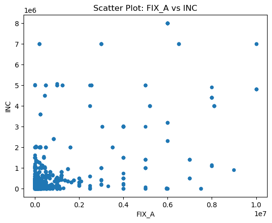

```python
# Create a scatter plot
data.plot.scatter(x='FIX_A', y='INC')
plt.title('Scatter Plot: FIX_A vs INC')
plt.show()
```

### Data Selection Methods

```python
# Different ways to select a column
income = data['INC']  # Dictionary-like notation
income = data.INC     # Attribute notation (if column name is valid Python identifier)

print("Income column:")
print(income.head())
```

```
Income column:
0    30000.0
1    38000.0
2    10000.0
3    60000.0
4    45000.0
Name: INC, dtype: float64
```

### Using iloc for Index-based Selection

```python
# Select first column (all rows)
income = data.iloc[:, 0]
print("First column (all rows):")
print(income.head())

# Select first 100 rows of first column
income = data.iloc[:100, 0]
print("\nFirst 100 rows of first column:")
print(income.head())
print("Length:", len(income))
```

```
First column (all rows):
0    30000.0
1    38000.0
2    10000.0
3    60000.0
4    45000.0
Name: INC, dtype: float64

First 100 rows of first column:
0    30000.0
1    38000.0
2    10000.0
3    60000.0
4    45000.0
Name: INC, dtype: float64
Length: 100
```

### Data Filtering

```python
# Filter rows where INC > 100000
income = data.INC[data.INC > 100000]
print("Income values > 100,000:")
print(income.head())
print("Number of high-income rows:", len(income))

# Filter using multiple conditions
data_filtered = data[(data.INC > 100000) & (data.FIX_A > 100000)]
print("\nFiltered data (both conditions):")
print(data_filtered.head())
print("Shape of filtered data:", data_filtered.shape)
```

```
Income values > 100,000:
5     180000.0
6     210000.0
7     120000.0
8     240000.0
18    300000.0
Name: INC, dtype: float64
Number of high-income rows: 1984

Filtered data (both conditions):
         INC      FIX_A
31  150000.0   400050.0
32  150000.0   400050.0
33  150000.0   400050.0
80  203750.0  1000095.0
81  203750.0  1000095.0
Shape of filtered data: (715, 2)
```

### Converting to NumPy Array

```python
# Convert pandas Series to NumPy array
income = data.INC.values
print("Income as NumPy array:")
print("Type:", type(income))
print("Shape:", income.shape)
print("First 10 values:", income[:10])
```

```
Income as NumPy array:
Type: <class 'numpy.ndarray'>
Shape: (67369,)
First 10 values: [ 30000.  38000.  10000.  60000.  45000. 180000. 210000. 120000. 240000.
 100000.]
```

## Key Concepts Summary

### NumPy:

- **Arrays**: Fundamental data structure for numerical computation
- **Vectorization**: Operations applied to entire arrays without loops
- **Broadcasting**: Operations between arrays of different shapes
- **Matrix Operations**: Linear algebra capabilities

### Pandas:

- **DataFrame**: 2D labeled data structure (like Excel spreadsheet)
- **Series**: 1D labeled array
- **Data Selection**: Multiple ways to select data (loc, iloc, boolean indexing)
- **Data Cleaning**: Filtering, handling missing values, etc.

### Important Differences:

- `ravel()` vs `flatten()`: ravel creates views, flatten creates copies
- `iloc` vs `loc`: iloc uses integer positions, loc uses labels
- Pandas vs NumPy: Pandas for labeled data, NumPy for numerical computation

## Exercise

1. Create a matrix `M` of shape (4,4) with random integers between 0 and 10. Compute the row sums and column means.
2. Using the provided CSV, filter rows where `INC` is between the 25th and 75th percentile. Display the filtered incomes using scatter plot.

```python
# use the quantile function to get the percentile
# q25 = df['INC'].quantile(0.50)
```

## Data Downloads using APIs

There are many ways to download data, including access to databases, web scraping, and APIs.

In this, example we will using the Yahoo Finance API.

Let's install first the Python package yfinance using the pip installer.

```python
# In your terminal, copy and paste the commands below:
pip install yfinance
pip install matplotlib
```

After installing yfinance and matplotlib. We can now import it to our notebook.

```python
import yfinance as yf
import matplotlib.pyplot as plt
```

To obtain financial data, we can use the download function, which takes the ticker symbol, period, and interval, among others, as arguments. Note that you can also specify start and end dates using the format YYYY-MM-DD.

By default, daily data is downloaded but you can obtain intra-daily data restricted to the last 30 days.

```python
data = yf.download("BTC-USD", period = "1d", interval = "1m")
print(type(data))
```

```
<class 'pandas.core.frame.DataFrame'>
```

The object data contains the downloaded financial data. In our example, we selected the value of Bitcoin in USD for a one-day period and a one-minute interval.

The `type()` function reveals that the object data is a Pandas DataFrame. The `head()` method is useful to explore the data structure.

```python
print(data.head())
```

```
Price                              Close           High            Low  \
Ticker                           BTC-USD        BTC-USD        BTC-USD
Datetime
2025-10-03 00:00:00+00:00  120606.320312  120606.320312  120606.320312
2025-10-03 00:01:00+00:00  120528.671875  120528.671875  120528.671875
2025-10-03 00:02:00+00:00  120516.992188  120516.992188  120516.992188
2025-10-03 00:03:00+00:00  120495.359375  120495.359375  120495.359375
2025-10-03 00:06:00+00:00  120439.125000  120439.125000  120439.125000

Price                               Open  Volume
Ticker                           BTC-USD BTC-USD
Datetime
2025-10-03 00:00:00+00:00  120606.320312       0
2025-10-03 00:01:00+00:00  120528.671875       0
2025-10-03 00:02:00+00:00  120516.992188       0
2025-10-03 00:03:00+00:00  120495.359375       0
2025-10-03 00:06:00+00:00  120439.125000       0
```

We plot closing prices using the attribute `Close` to refer to the Pandas Series, which is the argument for the `plot()` function. Finally, we save the figure and display.

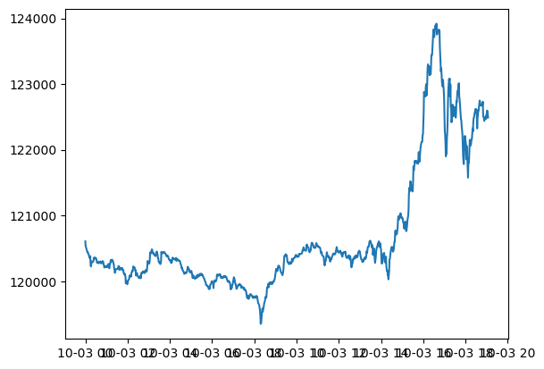

```python
plt.plot(data.Close)
plt.savefig(r"DW_bitcoin.png")
plt.show()
```

The next section explores a different API and combines country-level data in Pandas.

## Merging

Berkeley Earth (https://berkeleyearth.org/data/) provides access to global climate data. Data is available on country levels and based on geographical location (gridded data).

Let us explore time series data for India and the UK.

Following the links on the website, we navigate to a url that provides the country-level data as in a txt format.

Our first task is to download the data from the url using the requests library.

```python
# In your terminal install the following:

pip install numpy
pip install pandas
pip install matplotlib
```

All installed Python libraries are imported, followed by a list of countries and an empty list that will store our Pandas DataFrames.

```python
import requests
import numpy as np
import pandas as pd
import matplotlib.pyplot as plt

#Country list
countries = [ 'india', 'united-kingdom']

#Empty list of Pandas DataFrames

dfs = []
```

We construct urls from three strings. The first and the last part are identical for different countries. Hence, looping through the list of countries, we concatenate a unique string pointing to the respective url for each country.

Then, we use the requests library and obtain the data as a text file. Country-specific file names are constructed, and the data is written to txt files. These text files are loaded as Pandas DataFrames.

Finally, we name each DataFrame using the country name stored in the list of countries. Note that this code can be easily modified by adding additional country names.

Each DataFrame is added to the list of DataFrames called dfs using the `append()` method.

```python
for country in countries:
    url_part1 = "https://berkeley-earth-temperature.s3.us-west-1.amazonaws.com/Regional/TAVG/"
    url_part2 = "-TAVG-Trend.txt"
    url = url_part1 + country + url_part2

    response = requests.get(url, allow_redirects=True)

    if response.status_code != 200:
        print(f"Failed to fetch {country}: {response.status_code}")
        continue

    # Save file
    file_name = f"{country}_output.txt"
    with open(file_name, "w") as f:
        f.write(response.text)

    # Load data
    data = np.loadtxt(file_name, comments="%")
    df = pd.DataFrame(
        data[:, :6],
        columns=["year", "month", "m_ano", "m_temp", "a_ano", "a_temp"]
    )
    dfs.append(df)
    print(f"{country} loaded")
    print(df.head())
```

```
india loaded
     year  month  m_ano  m_temp  a_ano  a_temp
0  1816.0    5.0 -0.542   1.344    NaN     NaN
1  1816.0    6.0 -1.214   1.506    NaN     NaN
2  1816.0    7.0 -2.016   1.895 -1.702   1.419
3  1816.0    8.0 -1.575   1.040 -1.460   1.303
4  1816.0    9.0 -2.196   1.237 -1.475   1.343
united-kingdom loaded
     year  month  m_ano  m_temp  a_ano  a_temp
0  1750.0    1.0 -0.518   1.840    NaN     NaN
1  1750.0    2.0  1.769   2.245 -0.076   0.822
2  1750.0    3.0  1.915   2.662 -0.046   0.850
3  1750.0    4.0  0.229   1.575 -0.121   0.851
4  1750.0    5.0 -0.426   1.401 -0.375   0.837
```

The data download contains many variables. We need the year and months to identify the observation uniquely.

Apart from the identifiers, the monthly temperature anomaly, which refers to a deviation from historical averages, is obtained. Line 2 shows a list comprehension to reassign the list of DataFrames to datasets that contain the identifiers and the monthly temperature anomaly. Renaming the column to make it unique for different countries is useful. This is achieved using a loop over the `zip()` of DataFrames and countries.

The datasets with renamed variables are then added to a new list called dfs_renamed.

There are many different ways to merge datasets in Pandas. We use the `merge()` method in this example. Starting with the first dataset in the list of DataFrames, we merge the second dataset. The index can be readjusted.

Finally, we check the data structure using the `head()` and `tail()` methods.

```python
#Merge data
dfs = [df[['year', 'month', 'm_ano']] for df in dfs]
#Rename variable
dfs_renamed = []
for df, country in zip(dfs, countries):
    df = df.rename(columns={'m_ano': country})
    dfs_renamed.append(df)

#Merge DataFrames
df_merged = dfs_renamed[0].merge(dfs_renamed[1])
df_merged.reindex(['year', 'month'])
print(df_merged.head())
print(df_merged.tail())
```

```
     year  month  india  united-kingdom
0  1816.0    5.0 -0.542          -1.330
1  1816.0    6.0 -1.214          -1.604
2  1816.0    7.0 -2.016          -2.032
3  1816.0    8.0 -1.575          -1.854
4  1816.0    9.0 -2.196          -1.673
        year  month  india  united-kingdom
2451  2020.0    8.0  0.752           1.511
2452  2020.0    9.0  1.227           0.606
2453  2020.0   10.0  1.239          -0.037
2454  2020.0   11.0  0.612           2.212
2455  2020.0   12.0  0.725           1.359
```

Merging the data was successful. The following code creates a subplot comparing temperature anomalies across countries. Of course, the chapter on data visualization covers many ways to modify the appearance of the subplots.

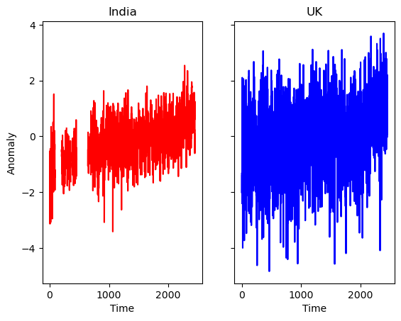

```python
#Plot temperatures
fig, axes = plt.subplots(nrows = 1, ncols = 2, sharey = True)
df_merged ['india'].plot(ax = axes [0], color = 'red')
df_merged ['united-kingdom'].plot(ax = axes[1], color = 'blue')
#Modifications
axes[0].set_xlabel('Time')
axes[1].set_xlabel('Time')
axes[0].set_ylabel('Anomaly')
axes[0].set_title('India')
axes[1].set_title('UK')
plt.savefig('DW_climate.png')
plt.show()
```

The figure depicts deviations of monthly temperatures from their historical averages for India and the UK.

Berkeley Earth offers a wide range of data on climate measures, which can be used for free. Climate risk has become an active research area and has emerged as an important driver of risk such as default risk.

## Outliers and Missing Values

Outliers are observations with 'extreme values', which can affect the robustness of statistical models. Some methods are more robust (e.g. quantile regressions) if outliers are present.

Scatter plots can identify outliers, which are 'far away' from other observations. It is good practice to start your data analysis with descriptive analyses of your variables. The following code can be applied to Pandas Series and the whole DataFrame. Note that we continue our analysis of household data.

Minimum and maximum values provide the range of a variable. Percentiles such as the 25-percentile and 75-percentile determine the interval that captures 50% of all observations.

Outliers are usually defined as values that are +3 standard deviation below or above the average value. What should we do with outliers after they are identified?

Many practitioners drop them from the dataset. However, this can be problematic as we do not know the underlying reason for extreme values.

Reasons include genuine mistakes (e.g. measurement errors) but also events that affect certain variables (e.g. economic shock or policy change). The latter can be modelled using dummy variables as outlined in the chapter on linear regressions.

Before outliers are removed, we suggest to explore the distribution of variables. Variables can be transformed (e.g. log transformation) if negative or positive skewness is present.

For instance, household income tends to exhibit positive skewness, i.e. a few large income values can be observed, with the majority of incomes below the mean. This positive skewness can be addressed by applying a natural logarithm.

NumPy can transform a Pandas Series as well as the Pandas method `transform()` in combination with Python's lambda functions. Note that lambda functions are unnamed functions in Python. They tend to be simple enough to fit into one line of code.

```python
print("Descriptive statistics: Pandas Series")
stats = data['INC'].describe()
print(stats)
print("Descriptive statistics: Pandas DataFrame")
stats = data.describe(include = 'all')
print(stats)
```

```
Descriptive statistics: Pandas Series
count    6.736900e+04
mean     2.692698e+04
std      2.026778e+05
min      0.000000e+00
25%      1.000000e+00
50%      3.000000e+02
75%      2.070010e+04
max      8.000000e+06
Name: INC, dtype: float64
Descriptive statistics: Pandas DataFrame
                INC         FIX_A
count  6.736900e+04  6.736900e+04
mean   2.692698e+04  1.682320e+04
std    2.026778e+05  2.509405e+05
min    0.000000e+00  0.000000e+00
25%    1.000000e+00  5.000000e+00
50%    3.000000e+02  1.500000e+01
75%    2.070010e+04  4.600000e+01
max    8.000000e+06  1.000050e+07
```

```python
# Log transformation using two different approaches
# data['ln_INC'] = np.log(data['INC'])
data['ln_INC'] = np.log1p(data['INC'])   # log(1+x)
# data['In_INC'] = data['INC'].transform(lambda x: np.log(x))
```

Hence, the skewness is reduced. This might be sufficient to address issues arising from outliers.

The following code replicates the figure above. Apart from histograms, box plots or Kernel density might be used to illustrate the distribution of variables.

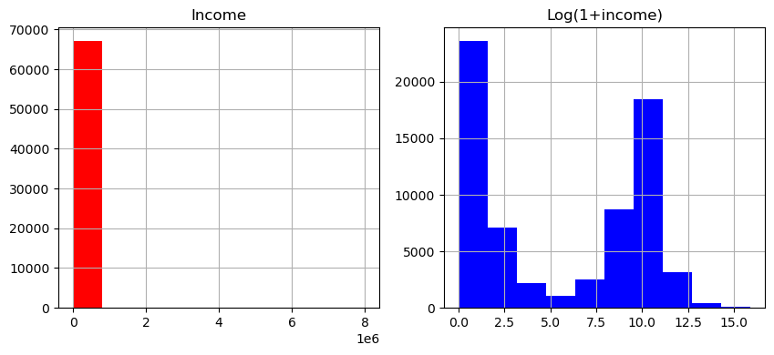

```python
# data['ln_INC'] = np.log1p(data['INC'])   # log(1+x) use this to show the income
fig, axes = plt.subplots(nrows=1, ncols=2, figsize=(10,4))
data['INC'].hist(ax=axes[0], color='red')
data['ln_INC'].hist(ax=axes[1], color='blue')

axes[0].set_title('Income')
axes[1].set_title('Log(1+income)')
plt.savefig('DW_transform.png')
plt.show()
```

If transformations or dummies fail to mitigate the impact of outliers, winsorization can be attempted. Winsorization replaces extreme values with the value at the 5-percentile and 95-percentile. Other cut-off points are common. Alternatively, robust methods can reduce or eliminate the effect of outliers on parameter estimates.

Missing values is another common problem in data wrangling. Basically, there are two options: (i) ignore missing values or (ii) try to predict missing values using existing data. In most applications in business analytics, missing data is ignored. To be precise, we adopt list-wise deletion, i.e. the observation (row) is removed from the model if one of the variables has missing values. This approach makes sense if data is easily available (e.g. data downloads).

In some disciplines, data is expensive to collect (e.g. medical trials). Accordingly, data imputation techniques have emerged for various data structures. In this course, we tend to adopt the list-wise deletion approach in line with most of the literature in business analytics.

## Simulations

Apart from analysing actual data, simulated data offers useful insights in many applications. Theoretical models might not predict deterministic outcomes but probabilistic insights can be derived. This is the case in many areas of business analytics. Many asset pricing or risk management models refer to stochastic modelling, where outcomes depend on stochastic processes.

This section illustrates the use of simulations to generate interest rates. The Vasicek (1977) model provides the underlying theory, which describes a continuous-time stochastic process. Time is continuous (in theory); hence, the letter d denotes the change in some variable. For instance, a basic continuous-time stochastic process for describing the dynamics of the short rate ($r$) is given by equation:

$$ dr = bdt + \sigma dz $$

Note that $r$ is the short rate, and dr denotes the change in the short rate. The change in time refers to dt or, equivalently, the length of the time interval (for a very small interval of time). Finally, dz denotes a random process, and b is the expected direction of the rate change. The impact of the random process is scaled by $ \sigma $.

The random nature of the change in the short rate stems from the random process $ dz $. The assumptions are that the random process follows a normal distribution with a mean of zero and a standard deviation of one (i.e. is a standardized normal distribution). Furthermore, the change in the short rate for any two different short intervals of time is independent. The expected value of the change in the short rate is equal to $ b $, the drift term.

The Vasicek (1977) model modifies equation above, assuming that interest rates are mean-reverting. The parameter $ \beta $ may be regarded as the equilibrium level of the short-term interest rate around which it evolves.

When r falls far below (above) its long-term value $ \beta $, the expected instantaneous variation of $r$ is positive (negative). In this case, the short-term rate will tend to move up (down). It will move towards its long-term value quickly when it is far from it and when the parameter a, the speed of return to the long-term mean, is high. Finally, $dW$ refers to a so-called Wiener process (Brownian Motion). $$ dr = a(y-r)dt + \rho dW $$

How can we simulate interest rates based on equation above? The main trick is to derive a discrete version of equation as time is not continuous in programming. So we note that $ dr \approx \Delta r_{t} = r_{t} - r_{t-1} $. We start by importing Python libraries.

```python
import numpy as np
import matplotlib.pyplot as plt
```

Then, we specified a new class that would do the simulation for us. As discussed in the section on object-oriented programming, we use the dunder `__init ()__` method to define a set of attributes, our model parameters.

These attributes include the number of iterations for our simulation $ N $, the time step $dt$ (time is discrete), the parameters $a, \beta, y$ (see Vasicek model equation), and an initial value for the interest rate `r0`. The latter is needed as we require to know $r_{t-1}$. Starting our simulation at time t = 1 suggests an initial value $r_{0}$, which is assigned to 4% as a default. Note that all arguments have default values (provided using an equal sign followed by the value). When we initialize an instance of the class, these default values apply, except we decide to use our own values.

```python
class Rate ():
    def __init__(self, N=1000, dt=0.05, rho=0.001, alpha=10, gamma=0.04 , r0=0.04):
    '''
    Parameters
    -----------------------
    N : Number of steps
    dt : Time steps
    rho : Scale
    alpha : Speed of adjustment
    gamma : Long - term equilibrium
    rO: Current interest rate
    '''

    self.N = N
    self.dt = dt
    self.rho = rho
    self.alpha = alpha
    self.gamma = gamma
    self.r0 = r0
```

There are different ways to implement equation (Vasicek). Usually, it is a good idea to separate processes as they could be re-used for other simulations.

Accordingly, we add a method `wiener(self)` to our class that returns a Wiener process. You notice the use of attributes in this method to incorporate parameter values.

```python
class Rate ():
    def __init__(self, N=1000, dt=0.05, rho=0.001, alpha=10, gamma=0.04 , r0=0.04):
        '''
        Parameters
        -----------------------
        N : Number of steps
        dt : Time steps
        rho : Scale
        alpha : Speed of adjustment
        gamma : Long - term equilibrium
        rO: Current interest rate
        '''

        self.N = N
        self.dt = dt
        self.rho = rho
        self.alpha = alpha
        self.gamma = gamma
        self.r0 = r0

    def wiener(self):
        '''
        Wiener process
        Returns
        --------------
        Array of realisations of Wiener process
        '''

        #Result vector
        out = np.zeros(self.N)

        #Initial value
        out[0]= np.sqrt(self.dt) * self.rho * np.random.normal (0, 1)

        for j in range(1, self.N):
            out[j] = out[j - 1] + np.sqrt(self.dt) * self. rho * np.random.normal (0,1)

        return out
```

Next, we use the `wiener(self)` method in our second method `vasicek(self)`, which completes the simulation.

```python
class Rate ():
    def __init__(self, N=1000, dt=0.05, rho=0.001, alpha=10, gamma=0.04 , r0=0.04):
        '''
        Parameters
        -----------------------
        N : Number of steps
        dt : Time steps
        rho : Scale
        alpha : Speed of adjustment
        gamma : Long - term equilibrium
        rO: Current interest rate
        '''

        self.N = N
        self.dt = dt
        self.rho = rho
        self.alpha = alpha
        self.gamma = gamma
        self.r0 = r0

    def wiener(self):
        '''
        Wiener process
        Returns
        --------------
        Array of realisations of Wiener process
        '''

        #Result vector
        out = np.zeros(self.N)

        #Initial value
        out[0]= np.sqrt(self.dt) * self.rho * np.random.normal (0, 1)

        for j in range(1, self.N):
            out[j] = out[j - 1] + np.sqrt(self.dt) * self. rho * np.random.normal (0,1)

        return out

    def vasicek(self):
        '''
        Returns
        --------
        Array of simulated interest rates
        '''

        #Result vector
        out = np.zeros(self.N)

        #Initial value
        out[0] = self.r0

        #Wiener process
        w = Rate()
        w = w.wiener()

        for j in range(1, self.N):
            out[j] = out[j - 1] + self.alpha*(self.gamma - out[j - 1])*self.dt + w[j]
        return out
```

Finally, we initialize an instance and call the `vasicek(self)` method. The result is plotted below.

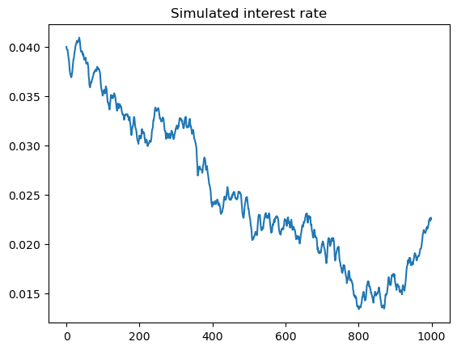

```python
#Initialise rate instance
rate = Rate()

#Apply Vasicek method
rate = rate.vasicek()

#Plot
plt.plot(rate)
plt.title('Simulated interest rate')
plt.savefig('DW_rate.png')
plt.show()
```

## Synthetic Data

Obtaining real data can be expensive and, in some settings, challenging (e.g. unobserved phenomena, rare events). Simulated data is an option if you have a theoretical model to derive the data. Basically, you need a data-generating process.

In the absence of a data-generating process, synthetic data might be an option. Synthetic data has many applications in testing and machine learning.

```python
#Install this on your terminal
pip install scikit-learn
pip install numpy
pip install pandas
pip install matplotlib
```

After the installation is complete, we make the following import statements. Note that we only import the make_classification class.

```python
import numpy as np
import pandas as pd
from sklearn.datasets import make_classification
```

Then we initialize an instance of the make_classification class, which requires two variables: the data matrix X and the array or classifications y, the dependent variable. Note that the `make_classification` class provides default settings for arguments.

In our example, we make a few changes.

For instance, we only want two dimensions (features or independent variables) and no redundant features. Redundant features are variables that do not contain any information. They are constructed from informative features using linear models with random coefficients. Finally, we create 200 artificial observations. Note that the resulting data matrix X and classifications y are NumPy arrays.

```python
#Data matrix X and response y
X, y = make_classification(
    n_samples = 200,
    n_features = 2,
    n_redundant = 0,
    n_clusters_per_class =1
)

#Data matrix
print(X)
print(type(X))

#Response (classification)

print(y)
print(type(y))
```

```
[[ 0.13244198  0.00591908]
 [ 0.32238464  1.3387133 ]
 [-0.74037308 -0.57391891]
 [-1.7023395  -1.67639714]
 [-1.0568173   0.5081343 ]
 [-2.17789879 -2.125118  ]
 [ 2.05943069  2.31490841]
 [-0.96631202 -0.94398139]
 [-0.05242191 -0.22204261]
 [ 1.30954134 -0.26099473]
 [-1.35953979 -1.16182035]
 [-1.69293388 -1.69040868]
 [ 0.3557075  -0.3235756 ]
 [ 0.4132443  -1.02485195]
 [-0.482591   -0.5183096 ]
 [-1.58206241 -1.54488271]
 [ 0.44624703  1.01410412]
 [ 0.50946957  0.49021388]
 [ 1.05053878  2.3811697 ]
 [ 0.57146151  1.88159723]
 [ 2.61477899  2.7757172 ]
 [ 1.55573065  1.16900573]
 [ 2.78557846  0.28252693]
 [ 1.61681489  1.77749127]
 [-0.76605319 -0.65055966]
 [ 0.27229333  2.3700131 ]
 [-1.70810235 -1.61440819]
 [ 0.66394771  0.81771835]
 [ 0.79098182  1.9540021 ]
 [-0.97214184 -0.9333899 ]
 [-0.62068306 -0.73442053]
 [ 2.38784053  1.69557698]
 [-0.95955931 -0.92346905]
 [ 2.53812427  2.39226452]
 [ 1.22491894  0.62087835]
 [ 0.79406643  0.7801381 ]
 [-1.65284061 -1.54339978]
 [ 2.37829293  1.53174445]
 [ 0.43156474  0.4155515 ]
 [-1.59557899 -1.50029359]
```

[output cut: 153 more lines]

```
 [ 2.38027766  2.24913188]
 [-0.77419712 -0.96207562]
 [ 1.58451725  1.88560065]
 [ 1.12917343 -0.25940937]
 [ 1.88598351  3.14461378]
 [ 1.59306354 -1.01590644]
 [ 1.07136697  2.8274225 ]]
<class 'numpy.ndarray'>
[0 1 0 0 1 0 1 0 0 1 0 0 1 1 0 0 1 0 1 1 1 1 1 1 0 1 0 1 1 0 0 1 0 1 1 0 0
 1 0 0 1 0 0 0 1 0 1 1 0 0 1 0 1 0 1 0 0 1 0 0 0 0 1 1 0 0 0 0 0 0 0 0 1 0
 0 1 1 1 1 0 1 1 0 1 1 0 0 1 1 1 1 1 1 1 1 1 0 0 1 1 0 1 0 1 0 0 1 0 0 0 0
 0 0 1 1 0 1 1 1 0 0 0 1 1 1 0 1 1 1 0 0 1 1 0 0 0 1 0 1 1 1 1 0 1 1 1 0 0
 1 0 0 0 1 1 1 0 0 0 1 1 0 0 0 0 0 0 0 1 1 0 1 1 1 1 0 1 0 0 1 0 1 1 0 0 1
 0 1 0 0 0 1 1 0 1 0 1 1 1 1 1]
<class 'numpy.ndarray'>
```

We convert the NumPy arrays into a Pandas DataFrame and a Pandas Series using the respective function and passing the arrays. The resulting list is an argument in the concat() function, which merges the Pandas objects horizontally, indicated by the axis=1 option. It is useful to change the column names and check the synthetic data.

```python
#Merge converted DataFrame and Series
df = pd.concat([pd.DataFrame(X), pd.Series(y)], axis=1)

#Rename columns
df.columns = ['x1', 'x2', 'y']
print(df.head())
print(df.tail())
```

```
         x1        x2  y
0  0.132442  0.005919  0
1  0.322385  1.338713  1
2 -0.740373 -0.573919  0
3 -1.702340 -1.676397  0
4 -1.056817  0.508134  1
           x1        x2  y
195  1.584517  1.885601  1
196  1.129173 -0.259409  1
197  1.885984  3.144614  1
198  1.593064 -1.015906  1
199  1.071367  2.827422  1
```

There are many alternative Python packages, e.g. faker, that generate synthetic data. However, given its importance in machine learning, scikit- learn is a prominent choice.

## Summary

This chapter introduced data wrangling and introduced the most prominent Python libraries, including NumPy, Pandas, and scikit-learn. Each library has been extensively covered in the literature (McKinney, 2012; Molin, 2019). We focused on a brief introduction, stressing the importance of problem-based learning at an early stage in your learning journey.

Data wrangling includes downloading or collecting data, exploring data structures, reshaping data, checking for outliers, and addressing missing values. These are essential tasks. Sadly, we have seen many cases in applied and academic research where crucial steps in the process were skipped. Even the best machine learning tool will struggle if you feed it with low-quality data.

## Machine Problem

Imagine you are trying to develop a strategy to win at Roulette. The idea is the following. You only bet using 50: 50 bets. Of course, one has to note that they are not quite 50: 50 as the green 0 ensures that the bank has an advantage. You start with a fixed bet of x, which you can modify at the start of the game.

If you win, you continue with your initial bet. If you lose, you double your bet in the next round. After winning, you adjust your bet back to the initial bet. The idea is that you can recover from any loss using this betting strategy. Historically, some casinos banned this strategy. As far as we know, this strategy is no longer considered against the rules.

Your task is to build a Python code that can run a simulation of this strategy. Implement the strategy based on betting on even or odd numbers.

Your initial cash position, the number of simulated games, and the initial value of the bet should be model parameters. Your simulation should show the gambler's cash position.